# Survival analysis tutorial: gene expression and patient outcome in breast cancer

A first introduction using the METABRIC dataset

2026-08-13

# 1. What is survival analysis?

Survival analysis answers one question: **do patients in one group live longer than patients in another group?**

In this tutorial we divide breast cancer patients into two groups, based on how much of one gene their tumour expresses:

- **High** group: expression above the middle value
- **Low** group: expression below the middle value

Then we compare how long the patients in each group survive.

## Two things we need for every patient

Survival analysis needs two pieces of information about each patient:

1. **Time** : how many months the patient was followed by the doctors.
2. **Event** : did the thing we are measuring happen during that time? We write this as a number: `1` means yes, `0` means no.

## Censoring: an important idea

Some patients were still alive when the study ended. We do not know how long they lived after that. We only know they were alive up to a certain date.

These patients are called **censored**. We write `event = 0` for them.

We do not remove censored patients. Their information is still useful: they tell us the patient survived at least until that time. Survival analysis is designed to use this partial information correctly.

## The Kaplan-Meier curve

The **Kaplan-Meier curve** (also called a KM curve) is a picture of survival over time.

- The vertical axis shows the probability of being alive, from 1.0 (100%) down to 0.
- The horizontal axis shows time, in months.
- The line starts at 1.0, because at the beginning every patient is alive.
- Every time a patient dies, the line steps down a little.
- When two groups are compared, we draw one line per group.

**If one line stays above the other line, that group has better survival.**

## Two survival endpoints in this tutorial

We will look at two different definitions of “the event”:

- **Overall survival (OS)** : the event is **death from any cause**. It does not matter what the patient died of.
- **Relapse-free survival (RFS)** : the event is **the cancer coming back** (also called relapse or recurrence).

# 2. Install the software packages

This step installs the R packages we need. A package is a collection of extra functions.

Some packages come from **CRAN** (the general R repository) and some come from **Bioconductor** (a repository for biology packages).

You only need to run this once. If a package is already installed, it will be skipped.

```r
# Packages from CRAN
cran_packages <- c("BiocManager", "survival", "survminer", "knitr")

for (p in cran_packages) {
  if (!requireNamespace(p, quietly = TRUE)) {
    install.packages(p, repos = "https://cloud.r-project.org")
  }
}

# Packages from Bioconductor (these need BiocManager, installed above)
bioc_packages <- c("cBioPortalData", "MultiAssayExperiment")

for (p in bioc_packages) {
  if (!requireNamespace(p, quietly = TRUE)) {
    BiocManager::install(p, ask = FALSE, update = FALSE)
  }
}
```

## Check that everything installed correctly

This step confirms that every package is really available. If any package shows `FALSE`, the code will stop with an error message telling you which one failed.

```r
all_packages <- c(cran_packages, bioc_packages)

installed <- vapply(all_packages, requireNamespace, logical(1), quietly = TRUE)

knitr::kable(data.frame(Package = all_packages, Installed = installed),
             caption = "Package installation check")
```

Package installation check

|  | Package | Installed |
| --- | --- | --- |
| BiocManager | BiocManager | TRUE |
| survival | survival | TRUE |
| survminer | survminer | TRUE |
| knitr | knitr | TRUE |
| cBioPortalData | cBioPortalData | TRUE |
| MultiAssayExperiment | MultiAssayExperiment | TRUE |

```r
if (!all(installed)) {
  stop("These packages did not install: ",
       paste(all_packages[!installed], collapse = ", "))
}
```

> **Note on package names.** In this tutorial every function is written with the package name in front of it, like `survival::coxph()`. The two colons `::` mean “use the function `coxph` from the package `survival`”. This makes the code clearer, because you can always see which package each function comes from.

# 3. Download the METABRIC dataset

METABRIC is a study of about 2,000 breast cancer patients. For each patient we have:

- the expression level of every gene in the tumour
- clinical information, including survival time and whether the patient died

The code below downloads the dataset from cBioPortal, a public website that stores cancer genomics data.

**This download is large (a few hundred megabytes) and can take several minutes.** It only needs to happen once. After the download, we save the data to a file called `metabric_data.rds` on your computer. The next time you run this document, the code loads that file instead of downloading again.

```r
data_file <- "metabric_data.rds"

if (file.exists(data_file)) {
  metabric <- readRDS(data_file)
} else {
  metabric <- cBioPortalData::cBioDataPack("brca_metabric")
  saveRDS(metabric, data_file)
}
```

## Take the two tables we need

The downloaded object contains many different types of data. We only need two tables.

- **Expression table**: how much each gene is expressed, in each patient. Rows are genes, columns are patients.
- **Clinical table**: information about each patient, including survival.

```r
# Gene expression (rows = genes, columns = patients)
expression <- MultiAssayExperiment::assay(metabric[["mrna_illumina_microarray"]])

# Clinical information (rows = patients)
clinical <- as.data.frame(MultiAssayExperiment::colData(metabric))

# How big are these tables?
cat("Expression table:", nrow(expression), "genes x", ncol(expression), "patients\n")
```

```
## Expression table: 20603 genes x 1980 patients
```

```r
cat("Clinical table:  ", nrow(clinical), "patients x", ncol(clinical), "columns\n")
```

```
## Clinical table:   2491 patients x 36 columns
```

# 4. Choose a gene

We will study the gene **MKI67**.

MKI67 makes a protein called **Ki-67**. Ki-67 is only present in cells that are dividing. Therefore, a tumour with high MKI67 expression is a tumour where many cells are dividing quickly.

Fast-dividing tumours usually grow faster and spread earlier. So we expect:

> **High MKI67 expression should be connected to worse survival.**

Ki-67 is not only used in research. Doctors already measure it in the clinic to help describe how aggressive a breast tumour is. This makes it a good and realistic example for a first analysis.

```r
gene_of_interest <- "MKI67"

# Check the gene exists in the expression table
if (!gene_of_interest %in% rownames(expression)) {
  stop("This gene is not in the dataset: ", gene_of_interest)
}
```

> **To study a different gene later**, change only the name in `gene_of_interest` above, then run the document again. Everything else works automatically.

# 5. Build the table for the analysis

Now we build one simple table. Each row is one patient. The columns are:

| Column | Meaning |
| --- | --- |
| `patient_id` | The identity code of the patient |
| `expression` | How much the gene is expressed in this patient’s tumour |
| `group` | `High` or `Low`, decided by the middle value (median) |
| `os_months` | Overall survival: months of follow-up |
| `os_event` | Overall survival: 1 = died, 0 = still alive (censored) |
| `rfs_months` | Relapse-free survival: months of follow-up |
| `rfs_event` | Relapse-free survival: 1 = cancer returned, 0 = did not return (censored) |

## About the High and Low groups

We use the **median** to split the patients. The median is the middle value: half the patients are above it and half are below it. This gives two groups of equal size.

## About the event columns

In the original data, the status is written as text, for example `"1:DECEASED"` or `"0:LIVING"`. Survival analysis needs a number. So we convert the text to `1` or `0`.

```r
# Take the expression values of our gene, for every patient
gene_values <- as.numeric(expression[gene_of_interest, ])

# Start the table
patients <- data.frame(
  patient_id = colnames(expression),
  expression = gene_values
)

# Add the clinical information for the same patients
patients <- merge(patients, clinical, by.x = "patient_id", by.y = "row.names")

# Split patients into High and Low, using the median
median_value <- stats::median(patients$expression, na.rm = TRUE)

patients$group <- factor(
  ifelse(patients$expression >= median_value, "High", "Low"),
  levels = c("Low", "High")     # "Low" is the reference group
)

# Overall survival: time and event
patients$os_months <- patients$OS_MONTHS
patients$os_event  <- as.integer(grepl("^1", patients$OS_STATUS))   # 1 = died

# Relapse-free survival: time and event
patients$rfs_months <- patients$RFS_MONTHS
patients$rfs_event  <- as.integer(grepl("^1", patients$RFS_STATUS)) # 1 = relapsed

# Look at the result
knitr::kable(head(patients[, c("patient_id", "expression", "group",
                               "os_months", "os_event",
                               "rfs_months", "rfs_event")]),
             caption = "First six patients in the analysis table")
```

First six patients in the analysis table

| patient_id | expression | group | os_months | os_event | rfs_months | rfs_event |
| --- | --- | --- | --- | --- | --- | --- |
| MB-0000 | 5.494254 | Low | 140.50000 | 0 | 140.500000 | 0 |
| MB-0002 | 5.451007 | Low | 84.63333 | 0 | 84.633333 | 0 |
| MB-0005 | 5.427919 | Low | 163.70000 | 1 | 153.300000 | 1 |
| MB-0006 | 5.488309 | Low | 164.93333 | 0 | 164.933333 | 0 |
| MB-0008 | 5.629876 | Low | 41.36667 | 1 | 18.800000 | 1 |
| MB-0010 | 6.046045 | High | 7.80000 | 1 | 2.933333 | 1 |

## How many patients are in each group?

```r
knitr::kable(as.data.frame(table(Group = patients$group), responseName = "Patients"),
             caption = paste("Number of patients in each", gene_of_interest, "group"))
```

Number of patients in each MKI67 group

| Group | Patients |
| --- | --- |
| Low | 990 |
| High | 990 |

# 6. Draw the Kaplan-Meier curves

This small function draws one Kaplan-Meier plot. We will use it two times: once for overall survival, and once for relapse-free survival.

The subtitle of each plot also shows the **hazard ratio**. This number is explained in section 8.

```r
draw_km_plot <- function(time_column, event_column, plot_title) {

  # Keep only patients who have all three values
  d <- patients[stats::complete.cases(
         patients[, c(time_column, event_column, "group")]), ]

  # Give the columns simple names
  d$time  <- d[[time_column]]
  d$event <- d[[event_column]]

  # Hazard ratio, shown in the subtitle (explained in section 8)
  cox <- survival::coxph(survival::Surv(time, event) ~ group, data = d)
  ci  <- summary(cox)$conf.int
  subtitle_text <- sprintf(
    "Hazard ratio (High vs Low) = %.2f (95%% CI %.2f to %.2f)  |  %d patients, %d events",
    ci[1, "exp(coef)"], ci[1, "lower .95"], ci[1, "upper .95"],
    nrow(d), sum(d$event))

  # Calculate the survival curves for the two groups
  fit <- survival::survfit(survival::Surv(time, event) ~ group, data = d)

  # Draw the plot
  survminer::ggsurvplot(
    fit, data = d,
    pval = TRUE,                                   # show the log-rank p-value
    conf.int = TRUE,                               # show the uncertainty band
    palette = c("#377EB8", "#E41A1C"),             # blue = Low, red = High
    legend.title = gene_of_interest,
    legend.labs = c("Low", "High"),
    xlab = "Time (months)",
    ylab = "Probability of survival",
    title = plot_title,
    subtitle = subtitle_text,
    break.time.by = 50,
    risk.table = TRUE,                             # table of patients still followed
    risk.table.title = "Number of patients still being followed",
    risk.table.height = 0.28,
    risk.table.y.text = FALSE,
    ggtheme = ggplot2::theme_bw(base_size = 13)
  )
}
```

## Overall survival

Here the event is **death from any cause**.

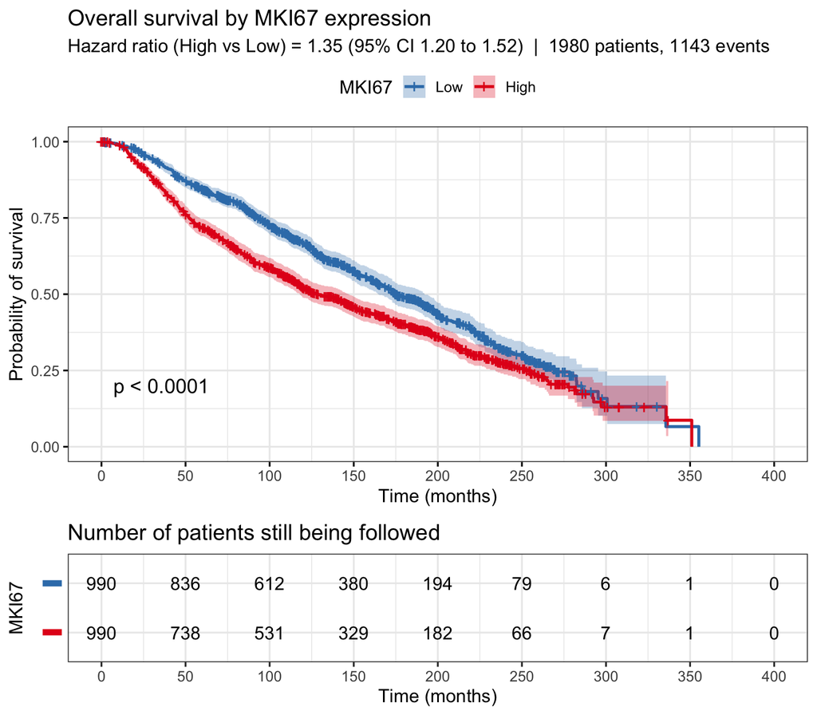

```r
draw_km_plot("os_months", "os_event",
             paste("Overall survival by", gene_of_interest, "expression"))
```

## Relapse-free survival

Here the event is **the cancer coming back**.

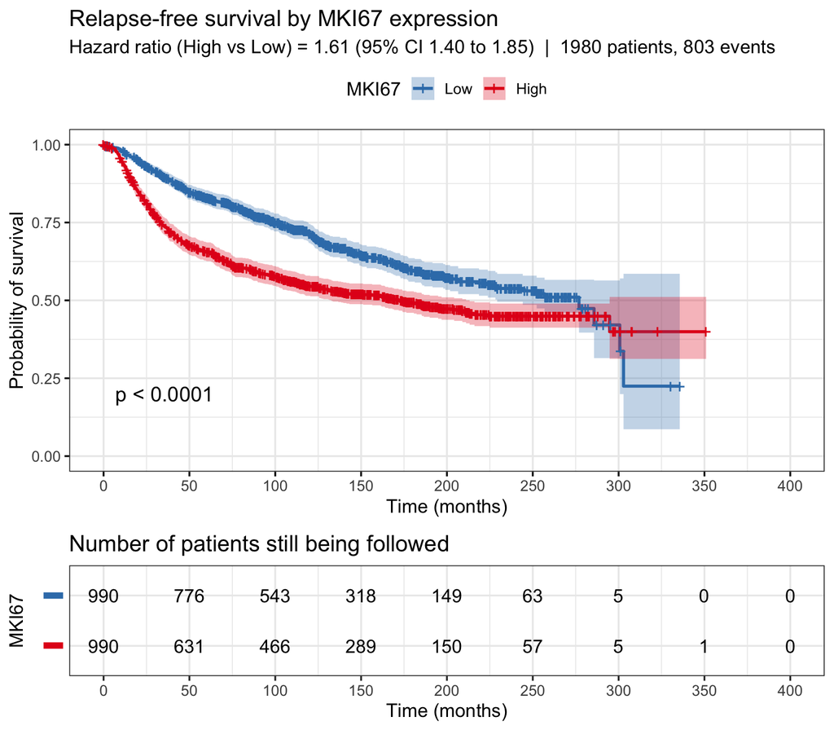

```r
draw_km_plot("rfs_months", "rfs_event",
             paste("Relapse-free survival by", gene_of_interest, "expression"))
```

# 7. How to read these plots

## The two coloured lines

Each line is one group. **Blue is the Low group. Red is the High group.**

The line that stays **higher** on the plot is the group with **better survival**.

## The p-value

The number written as `p = ...` is the result of a statistical test called the **log-rank test**. It answers this question:

> If the two groups really had the same survival, how likely is it that we would see a difference as large as this one, only by chance?
- A **small** p-value (usually below 0.05) means the difference is unlikely to be caused by chance. We say the difference is *statistically significant*.
- A **large** p-value means we did not find clear evidence of a difference.

Important: a small p-value tells you the difference is probably real. It does **not** tell you the difference is large or medically important.

## The shaded bands

The pale colour around each line shows the **uncertainty**. When the band is narrow, the estimate is precise. When the band is wide, we are less sure about the exact position of the line.

## The table below the plot

This table shows **how many patients were still being followed** at each time point.

This number becomes smaller over time, for two reasons: some patients had the event, and some patients reached the end of their follow-up (they were censored).

**This table is important.** On the right side of the plot, the number of patients is usually very small. The curve in that region is based on only a few people, so it is not reliable. Always look at the numbers before you believe the end of a curve.

# 8. Cox regression and the hazard ratio

The Kaplan-Meier curve shows us the *shape* of survival, and the p-value tells us whether the two groups are different. But neither of them tells us **how big** the difference is.

For that we use **Cox regression** (also called the Cox proportional hazards model). Cox regression gives us one number that measures the size of the difference: the **hazard ratio**.

## What is a hazard?

The **hazard** is the risk of the event happening at this moment, for the patients who have survived until now.

## What is a hazard ratio?

The **hazard ratio (HR)** compares the hazard of one group to the hazard of the other group. In this tutorial it compares the High group to the Low group.

| Hazard ratio | Meaning |
| --- | --- |
| **HR = 1** | The two groups have the same risk. No difference. |
| **HR > 1** | The High group has **more** risk. High expression is connected to **worse** survival. |
| **HR < 1** | The High group has **less** risk. High expression is connected to **better** survival. |

You can read the number directly as a percentage:

- HR = 1.50 means the High group has **50% more** risk.
- HR = 0.70 means the High group has **30% less** risk.

## The confidence interval

The hazard ratio is an estimate, so it comes with a **95% confidence interval (CI)**. The confidence interval is the range of values that are compatible with the data.

The important rule:

> **If the confidence interval does not include 1, the result is statistically significant.**

> If the confidence interval does include 1, we cannot exclude the possibility that there is no difference.

For example, an HR of 1.50 with CI from 1.20 to 1.90 does not include 1, so it is significant. An HR of 1.50 with CI from 0.90 to 2.50 does include 1, so it is not significant, even though the estimate looks large.

## Calculate the hazard ratios

```r
hazard_ratio_table <- function(time_column, event_column, endpoint_name) {

  d <- patients[stats::complete.cases(
         patients[, c(time_column, event_column, "group")]), ]
  d$time  <- d[[time_column]]
  d$event <- d[[event_column]]

  model <- survival::coxph(survival::Surv(time, event) ~ group, data = d)
  s     <- summary(model)

  data.frame(
    Endpoint          = endpoint_name,
    Comparison        = "High vs Low",
    Patients          = s$n,
    Events            = s$nevent,
    `Hazard ratio`    = round(s$conf.int[1, "exp(coef)"], 2),
    `CI lower`        = round(s$conf.int[1, "lower .95"], 2),
    `CI upper`        = round(s$conf.int[1, "upper .95"], 2),
    `p-value`         = signif(s$coefficients[1, "Pr(>|z|)"], 3),
    check.names = FALSE, row.names = NULL
  )
}

knitr::kable(
  rbind(hazard_ratio_table("os_months",  "os_event",  "Overall survival"),
        hazard_ratio_table("rfs_months", "rfs_event", "Relapse-free survival")),
  caption = paste("Cox regression:", gene_of_interest,
                  "High vs Low. HR above 1 means worse survival.")
)
```

Cox regression: MKI67 High vs Low. HR above 1 means worse survival.

| Endpoint | Comparison | Patients | Events | Hazard ratio | CI lower | CI upper | p-value |
| --- | --- | --- | --- | --- | --- | --- | --- |
| Overall survival | High vs Low | 1980 | 1143 | 1.35 | 1.2 | 1.52 | 4e-07 |
| Relapse-free survival | High vs Low | 1980 | 803 | 1.61 | 1.4 | 1.85 | 0e+00 |

## How to read this table

Look at the three numbers together, in this order:

1. **Hazard ratio** : how big is the difference, and in which direction?
2. **CI lower and CI upper** : does this range include 1? If not, the result is significant.
3. **p-value** : this should agree with the confidence interval. A p-value below 0.05 goes together with a confidence interval that does not include 1.

The p-value here comes from the Cox model. It is calculated in a slightly different way from the log-rank p-value on the plot, so the two numbers can be very slightly different. This is normal. They almost always lead to the same conclusion.

# 9. Median survival time

The **median survival time** is the time at which half of the patients in a group have had the event. On the plot, it is the time where the curve crosses 0.5 on the vertical axis.

If a group survives well, the curve may never reach 0.5. In that case the median cannot be calculated, and the table shows `NA`.

```r
median_table <- function(time_column, event_column, endpoint_name) {
  d <- patients[stats::complete.cases(
         patients[, c(time_column, event_column, "group")]), ]
  d$time  <- d[[time_column]]
  d$event <- d[[event_column]]

  fit <- survival::survfit(survival::Surv(time, event) ~ group, data = d)
  s   <- summary(fit)$table

  data.frame(
    Endpoint = endpoint_name,
    Group    = c("Low", "High"),
    Patients = s[, "records"],
    Events   = s[, "events"],
    `Median survival (months)` = round(s[, "median"], 1),
    check.names = FALSE, row.names = NULL
  )
}

knitr::kable(
  rbind(median_table("os_months",  "os_event",  "Overall survival"),
        median_table("rfs_months", "rfs_event", "Relapse-free survival")),
  caption = paste("Median survival time by", gene_of_interest, "group")
)
```

Median survival time by MKI67 group

| Endpoint | Group | Patients | Events | Median survival (months) |
| --- | --- | --- | --- | --- |
| Overall survival | Low | 990 | 517 | 174.8 |
| Overall survival | High | 990 | 626 | 128.5 |
| Relapse-free survival | Low | 990 | 333 | 276.9 |
| Relapse-free survival | High | 990 | 470 | 171.9 |

# 10. Summary

In this tutorial you have:

1. Installed the required R packages.
2. Downloaded the METABRIC breast cancer dataset.
3. Chosen one gene, MKI67, and divided the patients into a High group and a Low group.
4. Drawn Kaplan-Meier curves for two endpoints: overall survival and relapse-free survival.
5. Calculated hazard ratios with Cox regression, to measure how big the difference is.
6. Read the curves, the p-value, the confidence interval, and the number of patients still being followed.

MKI67 marks dividing cells, so tumours with high MKI67 are growing quickly. The results show this clearly: patients with high MKI67 expression have worse survival, and the hazard ratio is above 1 for both endpoints.

## What to try next

- **Change the gene.** Go back to section 4 and put a different gene name in `gene_of_interest`. Then run the document again. Two good genes to try are `ESR1` (the oestrogen receptor, usually connected to *better* survival, so the hazard ratio should be below 1) and `AURKA` (another gene linked to cell division).
- **Note that not every gene will show a difference.** This is a normal and correct result. Most genes are not connected to survival.

## Two important limits of this analysis

- **This analysis does not adjust for anything else.** Patient age, tumour size and tumour grade also affect survival. Here we compare only High and Low expression, and nothing else. Cox regression can also include these other variables at the same time, which is called a *multivariable* model. That is the natural next step after this tutorial.
- **A statistical association is not a cause.** These results show that high MKI67 and worse survival happen together. They do not prove that MKI67 *causes* the worse outcome.